# Text Analytics (Northwestern University, MLDS 414)

# Notebook: Bag-of-Words Models

## Yuri Balasanov, © iLykei 2021-2024

##### Main text: Deep Learning for Natural Language Processing, © 2019 Jason Brownlee.

See also the [blog by Jason Brownlee](https://machinelearningmastery.com/about/)

The approach based on the so called bag-of-words models is the simplest method in NLP. It does not require any deep understanding of the language structure and is based on relative frequencies of words from certain vocabulary in the text.

A bag-of-words is a representation of text that describes the occurrence of words within a document and is based on two things:

- A vocabulary of known words.
- A measure of the presence of known words.

It is called a bag-of-words , because any information about the order or structure of words in the document is discarded. The model is only concerned with whether known words occur in the document, not where in the document.

Vocabulary is the key element of the model. It can be created using the given document or corpus of documents. Alternatively it can be one of standard vocabularies based on a large number of documents.

# The Movie Review Data

The Movie Review Data is a collection of movie reviews retrieved from the imdb.com website in the early 2000s by Bo Pang and Lillian Lee.

The reviews collected and made available as part of their research on natural language processing, were originally released in 2002. An updated and cleaned version was released in 2004, referred to as v2.0. The dataset contains 1,000 positive and 1,000 negative movie reviews drawn from an archive of the `rec.arts.movies.reviews` newsgroup hosted at IMDB. The reviews were written before 2002, with a cap of 20 reviews per author (312 authors total) per category.  
The authors refer to this dataset as the polarity dataset.

Some data preparation has already been done in the set. For example:

- Only English reviews selected
- Texts converted to lowercase
- White space added around punctuation like periods, commas, and brackets
- Texts split into one sentence per line

Download the Movie Review Polarity Dataset from [here](http://www.cs.cornell.edu/people/pabo/movie-review-data/review_polarity.tar.gz).

The archive with the data contains directory called `txt_sentoken` with two sub-directories in it called `neg` and `pos` for negative and positive reviews.  
Reviews are stored one per file with a naming convention from `cv000` to `cv999` for each of `neg` and `pos`.

Load one negative review, for example:

```python
import os
from pathlib import Path
dataPath = Path(os.getcwd()).parent.parent/"data"
# load one file
filename = dataPath/'txt_sentoken/neg/cv000_29416.txt'
# open the file as read only
file = open(filename, 'r')
# read all text
text = file.read()
# close the file
file.close()
print(text[:500])
```

```
plot : two teen couples go to a church party , drink and then drive .
they get into an accident .
one of the guys dies , but his girlfriend continues to see him in her life , and has nightmares .
what's the deal ?
watch the movie and " sorta " find out . . .
critique : a mind-fuck movie for the teen generation that touches on a very cool idea , but presents it in a very bad package .
which is what makes this review an even harder one to write , since i generally applaud films which attempt
```

Since loading review files is going to be a frequent task create a function that does that as part of processing pipeline.

```python
from os import listdir

# load doc into memory
def load_doc(filename):
    # open the file as read only
    file = open(filename, 'r')
    # read all text
    text = file.read()
    # close the file
    file.close()
    return text
```

Now create a function that can get a list of files in the directory using `listdir()`, then loading each file in a loop.

```python
# load all docs in a directory
def process_docs(directory):
    # walk through all files in the folder
    for filename in listdir(directory):
        # skip files that do not have the right extension
        if not filename.endswith(".txt"):
            next
        # create the full path of the file to open
        path = directory / filename
        # load document
        doc = load_doc(path)
        # print('Loaded %s' % filename)    # long printout
```

For example, we can now load each document in the negative directory using the `load_doc()` function.

```python
# specify directory to load
directory = dataPath/'txt_sentoken/neg'
process_docs(directory)
```

# Cleaning Data

First, split the data into tokens separated by space. Take the same negative review `'cv000_29416.txt'`, for example.

```python
# load the document
filename = dataPath/'txt_sentoken/neg/cv000_29416.txt'
text = load_doc(filename)
# split into tokens by white space
tokens = text.split()
print(tokens[:100])
```

```
['plot', ':', 'two', 'teen', 'couples', 'go', 'to', 'a', 'church', 'party', ',', 'drink', 'and', 'then', 'drive', '.', 'they', 'get', 'into', 'an', 'accident', '.', 'one', 'of', 'the', 'guys', 'dies', ',', 'but', 'his', 'girlfriend', 'continues', 'to', 'see', 'him', 'in', 'her', 'life', ',', 'and', …
```

Observing the tokens, get some hints about cleaning:

- Remove punctuation from words (e.g. ‘what’s’)
- Remove tokens that are just punctuation (e.g. ‘-’)
- Remove tokens that contain numbers (e.g. ‘10/10’)
- Remove tokens that have one character (e.g. ‘a’)
- Remove tokens that don’t have much meaning (e.g. ‘and’) and other stop words

For example, cleaning this review may look like this:

```python
from nltk.corpus import stopwords
import string
import re
```

```python
# turn a doc into clean tokens
def clean_doc(doc):
    # split into tokens by white space
    tokens = doc.split()
    # prepare regex for char filtering
    re_punc = re.compile('[%s]' % re.escape(string.punctuation))
    # remove punctuation from each word
    tokens = [re_punc.sub('', w) for w in tokens]
    # remove remaining tokens that are not alphabetic
    tokens = [word for word in tokens if word.isalpha()]
    # filter out stop words
    stop_words = set(stopwords.words('english'))
    tokens = [w for w in tokens if not w in stop_words]
    # filter out short tokens
    tokens = [word for word in tokens if len(word) > 1]
    return tokens
```

Apply the cleaning function to the review `'cv000_29416.txt'`.

```python
# load the document
filename = dataPath/'txt_sentoken/neg/cv000_29416.txt'
text = load_doc(filename)
tokens = clean_doc(text)
print(tokens[:100])
```

```
['plot', 'two', 'teen', 'couples', 'go', 'church', 'party', 'drink', 'drive', 'get', 'accident', 'one', 'guys', 'dies', 'girlfriend', 'continues', 'see', 'life', 'nightmares', 'whats', 'deal', 'watch', 'movie', 'sorta', 'find', 'critique', 'mindfuck', 'movie', 'teen', 'generation', 'touches', 'cool'…
```

# Creating Vocabulary

Size of vocabulary plays very important role. If it is not large enough many meaningful words may be missed in the analysis. On the other hand, if vocabulary is too large the words representation will be too sparse.  
If the vocabulary is created from the given corpus of documents load all the documents and then analyze words that need to be dropped or kept depending on the task.

Working with the vocabulary is convenient using a Counter, which is a dictionary of words and their counts with some additional functions.  
Create a new function processing a document and adding the words from it to the vocabulary.  
The function:

- Loads the document by calling `load_doc()`
- Cleans the loaded document using `clean_doc()`
- Adds all the tokens to the Counter and updates counts by calling the `update()` function on the counter object.

Below is a function called `add_doc_to_vocab()` that takes as arguments a document filename and a Counter vocabulary.

```python
from collections import Counter

# load doc and add to vocab
def add_doc_to_vocab(filename, vocab):
    # load doc
    doc = load_doc(filename)
    # clean doc
    tokens = clean_doc(doc)
    # update counts
    vocab.update(tokens)
```

Now update the function `process_docs(directory, vocab)` to call `add_doc_to_vocab()`.

```python
# load all docs in a directory
def process_docs(directory, vocab):  # new argument 'vocab'
    # walk through all files in the folder
    for filename in listdir(directory):
        # skip files that do not have the right extension
        if not filename.endswith(".txt"):
            next
        # create the full path of the file to open
        path = directory / filename
        # add doc to vocab
        add_doc_to_vocab(path, vocab) # loads, cleans document and updates counts
```

Now develop full vocabulary from all documents in the dataset.

```python
# define vocab
vocab = Counter()
# add all docs to vocab
process_docs(dataPath/'txt_sentoken/neg', vocab)
process_docs(dataPath/'txt_sentoken/pos', vocab)
# print the size of the vocab
print('Vocabulary size: ',len(vocab))
# print the top words in the vocab
print('\nTop 50 words in the vocabulary:\n',vocab.most_common(50))
```

```
Vocabulary size:  46557

Top 50 words in the vocabulary:
 [('film', 8860), ('one', 5521), ('movie', 5440), ('like', 3553), ('even', 2555), ('good', 2320), ('time', 2283), ('story', 2118), ('films', 2102), ('would', 2042), ('much', 2024), ('also', 1965), ('characters', 1947), ('get', 1921), ('character', 1906), ('two', 1825), ('first', 1768), ('see', 1730)…
```

Typically at the bottom of the vocabulary there are very rare words that appear in the documents only once or a few times. Such words are often not predictive and can be removed to reduce the size of the vocabulary.

```python
# keep tokens with > 2 occurrence
min_occurrence = 2
tokens = [k for k,c in vocab.items() if c >= min_occurrence]
print('Number of tokens with frequency >2: ',len(tokens))
print('Some tokens:\n',tokens[:20])
```

```
Number of tokens with frequency >2:  27139
Some tokens:
 ['comes', 'average', 'teenage', 'romantic', 'comedy', 'expect', 'negative', 'reviews', 'critics', 'left', 'right', 'predictable', 'unoriginal', 'forgettable', 'likely', 'three', 'adjectives', 'haunt', 'drive', 'released']
```

Reduction is very significaant: from 46557 to 27139.

Now save the chosen vocabulary of words to a new file as ASCII with one word per line. Function called `save_list()` saves a list of items, in this case, tokens to file, one per line.

```python
# save list to file
def save_list(lines, filename):
    data = '\n'.join(lines)
    file = open(filename, 'w')
    # write text
    file.write(data)
    file.close()

# save tokens to a vocabulary file
save_list(tokens, 'vocab.txt')
```

# Saving Prepared Data

The process of data cleaning and making vocabulary can now be used to prepare each movie review and save the prepared versions to the file ready for modeling.  
Load the vocabulary from `vocab.txt` and turn it into a set.  
Set is an unordered collection data type that is iterable, mutable and has no duplicate elements. The major advantage of using a set, as opposed to a list, is that it has a highly optimized method for checking whether a specific element is contained in the set.

```python
# load vocabulary
vocab_filename = 'vocab.txt'
vocab = load_doc(vocab_filename)
vocab = vocab.split()
vocab = set(vocab)
```

Print some of the vocabulary words

```python
import itertools
for i, val in enumerate(itertools.islice(vocab, 10)): print(val)
```

```
piling
inbred
keel
bat
kathryn
rhyme
endeavors
copout
mass
baptist
```

Next, clean the reviews, use the loaded vocab to filter out unwanted tokens, and save the clean reviews.  
Save all the positive reviews in one file and all the negative reviews in another file, with the filtered tokens separated by white space for each review on separate lines.

First, define a function `doc_to_line()` to process a document, clean it, filter it, and return it as a single line that could be saved in a file. The function takes a filename and vocabulary (as a set) as arguments. It calls the previously defined `load_doc()` and `clean_doc()` functions to load and tokenize the document.

```python
# load doc, clean and return line of tokens
def doc_to_line(filename, vocab):
    # load the doc
    doc = load_doc(filename)
    # clean doc
    tokens = clean_doc(doc)
    # filter by vocab
    tokens = [w for w in tokens if w in vocab]
    return ' '.join(tokens)
```

Now update function `process_docs()` to step through all reviews in a folder and convert them to lines by calling `doc_to_line()` for each document. The result is list of lines.

```python
# load all docs in a directory
def process_docs(directory, vocab):
    lines = list()
    # walk through all files in the folder
    for filename in listdir(directory):
        # skip files that do not have the right extension
        if not filename.endswith(".txt"):
            next
        # create the full path of the file to open
        path = directory / filename
        # load and clean the doc
        line = doc_to_line(path, vocab) # loads, cleans and filters by vocabulary
        # add to list
        lines.append(line)
    return lines
```

Apply the updated `process_docs(directory, vocab)` function to positive and negative reviews. Then use `save_list()` to save each list of processed reviews to a file.

```python
# prepare negative reviews
negative_lines = process_docs(dataPath/'txt_sentoken/neg', vocab)
save_list(negative_lines, 'negative.txt')
# prepare positive reviews
positive_lines = process_docs(dataPath/'txt_sentoken/pos', vocab)
save_list(positive_lines, 'positive.txt')
```

As a result two new files appear: `negative.txt` and `positive.txt`. They contain the prepared negative and positive reviews respectively. The data are ready for use in a bag-of-words or more advanced models.

# Bag-of-Words Model for Sentiment Analysis

Classification of movie reviews into two classes: favorable or not, is often called sentiment analysis. A popular technique for developing sentiment analysis models is to use a bag-of-words model that transforms documents into vectors where each word in the document is assigned a score.

In addition to the preprocessing the data in the previous section, separate the data into train and test. Use a common 90%-10% split. In particular, use the last 100 positive and last 100 negative reviews as test and the the remaining reviews as train sample. Modify the `process_docs(directory, vocab)` function to select train sample only and create vocabulary from it.

```python
# load all docs in a directory: modified to make train-test split
def process_docs(directory, vocab):
    # walk through all files in the folder
    for filename in listdir(directory):
        # skip any reviews in the test set
        if filename.startswith('cv9'):
            continue
        # create the full path of the file to open
        path = directory / filename
        # add doc to vocab
        add_doc_to_vocab(path, vocab)
```

Define the vocabulary of the train set.

```python
# define vocab
vocab = Counter()
# add all docs to vocab
process_docs(dataPath/'txt_sentoken/pos', vocab)
process_docs(dataPath/'txt_sentoken/neg', vocab)
# print the size of the vocab
print('Length of Vocabulary: ',len(vocab))
# print the top words in the vocab
print('Most common tokens:\n',vocab.most_common(50))
```

```
Length of Vocabulary:  44276
Most common tokens:
 [('film', 7983), ('one', 4946), ('movie', 4826), ('like', 3201), ('even', 2262), ('good', 2080), ('time', 2041), ('story', 1907), ('films', 1873), ('would', 1844), ('much', 1824), ('also', 1757), ('characters', 1735), ('get', 1724), ('character', 1703), ('two', 1643), ('first', 1588), ('see', 1557)…
```

Like before, reduce the size of the vocabulary by removing rare words and save the vocabulary in `vocab.txt`.

```python
# keep tokens with a min occurrence
min_occurrence = 2
tokens = [k for k,c in vocab.items() if c >= min_occurrence]
print('Reduced vocabulary length: ',len(tokens))
# save tokens to a vocabulary file
save_list(tokens, 'vocab.txt')
```

```
Reduced vocabulary length:  25767
```

## Bag of words representation

A bag-of-words model extracts features from the text. These features can be used as inputs for machine learning methods.

Each document is converted into a vector representation of the dimension equal to the size of the vocabulary.

Use the function `doc_to_line()` created earlier to load the document, clean it, filter words using the vocabulary and return the document as a line of tokens separated by white spaces.

Create another version of `process_docs()` that selects train set, cleans it and converts all documents from it into lines.

```python
# load all docs in a directory: turns docs into lines
def process_docs(directory, vocab):
    lines = list()
    # walk through all files in the folder
    for filename in listdir(directory):
        # skip any reviews in the test set
        if filename.startswith('cv9'):
            continue
        # create the full path of the file to open
        path = directory / filename
        # load and clean the doc
        line = doc_to_line(path, vocab)
        # add to list
        lines.append(line)
    return lines
```

Apply the process to positive and negative reviews, combine them together and prepare labels. That is done by the function:

```python
# load and clean a dataset
def load_clean_dataset(vocab):
    # load documents
    neg = process_docs(dataPath/'txt_sentoken/neg', vocab)
    pos = process_docs(dataPath/'txt_sentoken/pos', vocab)
    docs = neg + pos
    # prepare labels
    labels = [0 for _ in range(len(neg))] + [1 for _ in range(len(pos))]
    return docs, labels
```

Process the data using the saved vocabulary.

```python
# load the vocabulary
vocab_filename = 'vocab.txt'
vocab = load_doc(vocab_filename)
vocab = vocab.split()
vocab = set(vocab)
# load all training reviews
docs, labels = load_clean_dataset(vocab)
# summarize what we have
print('Length of documents: ',len(docs), '\nLength of labels: ',len(labels))
```

```
Length of documents:  1800
Length of labels:  1800
```

## Vector representations using Keras

Use Keras API to convert movie reviews into vectors. Create a function that creates tokenizer and fits it to the data.

```python
from tensorflow.keras.preprocessing.text import Tokenizer
# fit a tokenizer
def create_tokenizer(lines):
    tokenizer = Tokenizer()
    tokenizer.fit_on_texts(lines)
    return tokenizer
```

[output not shown]

The result is conversion of the vocabulary to a vector of dimension 25768.

Modify the process `process_docs()` again to process train and test sets separately. This is done by adding a flag `is_train`.

```python
# load all docs in a directory: prepare either train or test texts
def process_docs(directory, vocab, is_train):
    lines = list()
    # walk through all files in the folder
    for filename in listdir(directory):
        # skip any reviews in the test set
        if is_train and filename.startswith('cv9'):
            continue
        if not is_train and not filename.startswith('cv9'):
            continue
        # create the full path of the file to open
        path = directory / filename
        # load and clean the doc
        line = doc_to_line(path, vocab)
        # add to list
        lines.append(line)
    return lines
```

Similarly update `load_clean_dataset()` to run `process_docs()` with the flag `is_train` and return a NumPy array with labels.

```python
from numpy import array
# load and clean a dataset
def load_clean_dataset(vocab, is_train):
    # load documents
    neg = process_docs(dataPath/'txt_sentoken/neg', vocab, is_train)
    pos = process_docs(dataPath/'txt_sentoken/pos', vocab, is_train)
    docs = neg + pos
    # prepare labels
    labels = array([0 for _ in range(len(neg))] + [1 for _ in range(len(pos))])
    return docs, labels
```

Apply the function `load_clean_dataset(vocab, is_train)` to train and test data.

```python
# load all reviews
train_docs, ytrain = load_clean_dataset(vocab, True)
test_docs, ytest = load_clean_dataset(vocab, False)
```

Create the tokenizer and encode the documents using method `text_to_matrix(docs,mode)`. For now use the mode `freq` scoring the words by their frequency in the document.

```python
# create the tokenizer
tokenizer = create_tokenizer(train_docs)
# encode data
Xtrain = tokenizer.texts_to_matrix(train_docs, mode='freq')
Xtest = tokenizer.texts_to_matrix(test_docs, mode='freq')
print(Xtrain.shape, Xtest.shape)
```

```
(1800, 25768) (200, 25768)
```

## Classifying sentiment

Create simple sequential model to classify reviews by sentiment. The input layer size is the number of words in the vocabulary

```python
from tensorflow.keras.utils import plot_model
from tensorflow.keras.models import Sequential
from tensorflow.keras.layers import Dense
```

```python
# define the model
def define_model(n_words):
    # define network
    model = Sequential()
    model.add(Dense(50, input_shape=(n_words,), activation='relu'))
    model.add(Dense(1, activation='sigmoid'))
    # compile network
    model.compile(loss='binary_crossentropy', optimizer='adam', metrics=['accuracy'])
    return model
```

Create the model and plot it.

```python
# define the model
n_words = Xtest.shape[1]
model = define_model(n_words)
model.summary()
```

```
Model: "sequential"
_________________________________________________________________
 Layer (type)                Output Shape              Param #
=================================================================
 dense (Dense)               (None, 50)                1288450

 dense_1 (Dense)             (None, 1)                 51

=================================================================
Total params: 1,288,501
Trainable params: 1,288,501
Non-trainable params: 0
_________________________________________________________________
```

Plot the structure of the model saved in the file `model.png`

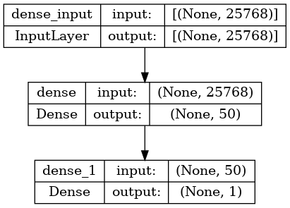

```python
plot_model(model, to_file='model.png', show_shapes=True)
```

Fit the model and evaluate it usinng test data.

```python
# fit network
model.fit(Xtrain, ytrain, epochs=10, verbose=0)
# evaluate
loss, acc = model.evaluate(Xtest, ytest, verbose=0)
print('Test Accuracy: %f' % (acc*100))
```

```
Test Accuracy: 87.500000
```

## Comparing word scoring methods

The function `text_to_matrix()` gives 4 scoring options:

- `binary`: words are scored as present (1) or absent
- `count`: integer count for each word
- `tfidf`: each word is scored based on their frequency, where words that are common across all documents are penalized
- `freq`: words are scored based on their frequencies.

To compare the scoring options create a function `prepare_data()` encoding the texts with the selected encoding mode.  
It creates the tokenizer, fits it on the training documents, then creates the train and test encodings using the chosen mode and given lists of train and test documents.

```python
def prepare_data(train_docs, test_docs, mode):
    # create the tokenizer
    tokenizer = Tokenizer()
    # fit the tokenizer on the documents
    tokenizer.fit_on_texts(train_docs)
    # encode training data set
    Xtrain = tokenizer.texts_to_matrix(train_docs, mode=mode)
    # encode training data set
    Xtest = tokenizer.texts_to_matrix(test_docs, mode=mode)
    return Xtrain, Xtest
```

In addition create function `evaluate_mode()` for evaluation of different models. It runs each model several times for more reliable evaluation.

```python
# evaluate a neural network model
def evaluate_mode(Xtrain, ytrain, Xtest, ytest):
    scores = list()
    n_repeats = 10
    n_words = Xtest.shape[1]
    for i in range(n_repeats):
        # define network
        model = define_model(n_words)
        # fit network
        model.fit(Xtrain, ytrain, epochs=10, verbose=0)
        # evaluate
        _, acc = model.evaluate(Xtest, ytest, verbose=0)
        scores.append(acc)
        print('%d accuracy: %s' % ((i+1), acc))
    return scores
```

```python
from pandas import DataFrame
from matplotlib import pyplot
# run experiment
modes = ['binary', 'count', 'tfidf', 'freq']
results = DataFrame()
for mode in modes:
    # prepare data for mode
    Xtrain, Xtest = prepare_data(train_docs, test_docs, mode)
    # evaluate model on data for mode
    results[mode] = evaluate_mode(Xtrain, ytrain, Xtest, ytest)
```

```
1 accuracy: 0.9200000166893005
2 accuracy: 0.9200000166893005
3 accuracy: 0.9350000023841858
4 accuracy: 0.9350000023841858
5 accuracy: 0.9150000214576721
6 accuracy: 0.9300000071525574
7 accuracy: 0.925000011920929
8 accuracy: 0.9399999976158142
9 accuracy: 0.9300000071525574
10 accuracy: 0.9350000023841858
1 accuracy: 0.8949999809265137
2 accuracy: 0.8949999809265137
3 accuracy: 0.8899999856948853
4 accuracy: 0.9049999713897705
5 accuracy: 0.8949999809265137
```

[output cut: 25 more lines]

Print the table with comparative summary statistics and show boxplot.

```
          binary      count      tfidf       freq
count  10.000000  10.000000  10.000000  10.000000
mean    0.928500   0.897000   0.877500   0.867500
std     0.008182   0.007528   0.010865   0.004859
min     0.915000   0.885000   0.860000   0.860000
25%     0.921250   0.895000   0.871250   0.865000
50%     0.930000   0.895000   0.877500   0.865000
75%     0.935000   0.902500   0.883750   0.870000
max     0.940000   0.910000   0.895000   0.875000
```

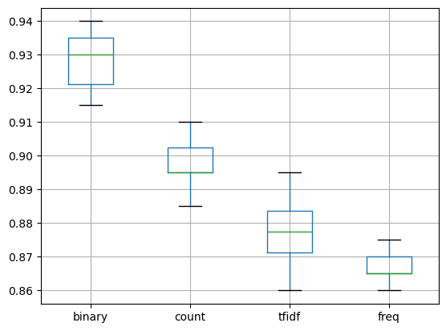

```python
# summarize results
print(results.describe())
# plot results
results.boxplot()
pyplot.show()
```

The binary method comes out the best.

## Predicting sentiment

Finally, use the preparation pipeline and the method to make predictions for new textual reviews.  
First, train a model on all of the available data.  
Use the binary mode for scoring the bag-of-words model that was shown to give the best results in the previous sections.  
Follow the same steps used to prepare the test data:

- Load the text
- Clean the documents
- Filter tokens by the chosen vocabulary
- Convert the remaining tokens to a line
- Encode it using the Tokenizer.

Then make a prediction.

Modify the function `process_docs()` to go through all document files in the specified directory and turn them into lines.

```python
# load all docs in a directory
def process_docs(directory, vocab):
    lines = list()
    # walk through all files in the folder
    for filename in listdir(directory):
        # create the full path of the file to open
        path = directory / filename
        # load and clean the doc
        line = doc_to_line(path, vocab)
        # add to list
        lines.append(line)
    return lines
```

Modify `load_clean_dataset()` without splitting into train/test samples.

```python
## load and clean a dataset: no train/test split necessary
def load_clean_dataset(vocab):
    # load documents
    neg = process_docs(dataPath/'txt_sentoken/neg', vocab)
    pos = process_docs(dataPath/'txt_sentoken/pos', vocab)
    docs = neg + pos
    # prepare labels
    labels = array([0 for _ in range(len(neg))] + [1 for _ in range(len(pos))])
    return docs, labels
```

Create `predict_sentiment()` which takes review, vocabulary, tokenizer and the trained model and returns the predicted sentiment.

```python
# classify a review as negative or positive
def predict_sentiment(review, vocab, tokenizer, model):
    # clean
    tokens = clean_doc(review)
    # filter by vocab
    tokens = [w for w in tokens if w in vocab]
    # convert to line
    line = ' '.join(tokens)
    # encode
    encoded = tokenizer.texts_to_matrix([line], mode='binary')
    # predict sentiment
    yhat = model.predict(encoded, verbose=0)
    # retrieve predicted percentage and label
    percent_pos = yhat[0,0]
    if round(percent_pos) == 0:
        return (1-percent_pos), 'NEGATIVE'
    return percent_pos, 'POSITIVE'
```

Test the prediction function in action.

```python
# load the vocabulary
vocab_filename = 'vocab.txt'
vocab = load_doc(vocab_filename)
vocab = set(vocab.split())
# load all reviews
train_docs, ytrain = load_clean_dataset(vocab)
test_docs, ytest = load_clean_dataset(vocab)
# create the tokenizer
tokenizer = create_tokenizer(train_docs)
# encode data
Xtrain = tokenizer.texts_to_matrix(train_docs, mode='binary')
Xtest = tokenizer.texts_to_matrix(test_docs, mode='binary')
# define network
n_words = Xtrain.shape[1]
model = define_model(n_words)
# fit network
model.fit(Xtrain, ytrain, epochs=10, verbose=0)
```

```
<keras.callbacks.History at 0x74d0b50ebf10>
```

```python
# test positive text
text = 'Best movie ever! It was great, I recommend it.'
percent, sentiment = predict_sentiment(text, vocab, tokenizer, model)
print('Review: [%s]\nSentiment: %s (%.3f%%)' % (text, sentiment, percent*100))
# test negative text
text = 'This is a bad movie.'
percent, sentiment = predict_sentiment(text, vocab, tokenizer, model)
print('Review: [%s]\nSentiment: %s (%.3f%%)' % (text, sentiment, percent*100))
```

```
Review: [Best movie ever! It was great, I recommend it.]
Sentiment: POSITIVE (54.933%)
Review: [This is a bad movie.]
Sentiment: NEGATIVE (64.889%)
```

These movie reviews were pretty obvious, they are classified correctly, but not with very high confidence.

But take a random review from the web:

“Citizen Kane” “The picture is very exciting to anyone who gets excited about how things are done in the movies… and in these things there is no doubt the picture is dramatic. But what goes on between the dramatic high points, the story? No. What goes on is talk and more talk. And while the stage may stand for this, the movies don’t.” – Otis Ferguson, The New Republic

Give this review for prediction of sentiment, appreciate the human ability to communicate with wit and sarcasm.

```python
text = 'The picture is very exciting to anyone who gets excited about how things are done in the movies… and in these things there is no doubt the picture is dramatic. But what goes on between the dramatic high points, the story? No. What goes on is talk and more talk. And while the stage may stand for this, the movies don’t.'
percent, sentiment = predict_sentiment(text, vocab, tokenizer, model)
print('Review: [%s]\nSentiment: %s (%.3f%%)' % (text, sentiment, percent*100))
```

```
Review: [The picture is very exciting to anyone who gets excited about how things are done in the movies… and in these things there is no doubt the picture is dramatic. But what goes on between the dramatic high points, the story? No. What goes on is talk and more talk. And while the stage may stand…
Sentiment: POSITIVE (55.123%)
```